# Prediction Assignment Writeup - Leonson Leveille

Leonson Leveille

15 juillet 2017

```r
library(plyr)
library(dplyr)
library(caret)
rm(list = ls())
gc()
```

```
##           used (Mb) gc trigger  (Mb) max used  (Mb)
## Ncells 1562634 83.5    2637877 140.9  2164898 115.7
## Vcells 1522047 11.7    2552219  19.5  2049057  15.7
```

Let’s import the data and take a look at it.

```r
data <- read.csv("pml-training.csv", stringsAsFactors = F, na.strings = c("NA", ""))
head(data)
```

```
##   X user_name raw_timestamp_part_1 raw_timestamp_part_2   cvtd_timestamp
## 1 1  carlitos           1323084231               788290 05/12/2011 11:23
## 2 2  carlitos           1323084231               808298 05/12/2011 11:23
## 3 3  carlitos           1323084231               820366 05/12/2011 11:23
## 4 4  carlitos           1323084232               120339 05/12/2011 11:23
## 5 5  carlitos           1323084232               196328 05/12/2011 11:23
## 6 6  carlitos           1323084232               304277 05/12/2011 11:23
##   new_window num_window roll_belt pitch_belt yaw_belt total_accel_belt
## 1         no         11      1.41       8.07    -94.4                3
## 2         no         11      1.41       8.07    -94.4                3
## 3         no         11      1.42       8.07    -94.4                3
## 4         no         12      1.48       8.05    -94.4                3
## 5         no         12      1.48       8.07    -94.4                3
## 6         no         12      1.45       8.06    -94.4                3
##   kurtosis_roll_belt kurtosis_picth_belt kurtosis_yaw_belt
```

[output cut: 265 more lines]

Seems that we do not need the first two variables and the cvtd_timestamp variable

```r
data <- subset(data, select = -c(X, user_name, cvtd_timestamp))
```

How many columns and rows do we have?

```r
dim(data)
```

```
## [1] 19622   157
```

We have 19622 rows and 157 variables. With that many variables, it may be a good choice to use PCA.

Let’s see if we have any NAs in this dataset.

```r
sapply(data, function(x) sum(is.na(x)))
```

```
##     raw_timestamp_part_1     raw_timestamp_part_2               new_window
##                        0                        0                        0
##               num_window                roll_belt               pitch_belt
##                        0                        0                        0
##                 yaw_belt         total_accel_belt       kurtosis_roll_belt
##                        0                        0                    19216
##      kurtosis_picth_belt        kurtosis_yaw_belt       skewness_roll_belt
##                    19216                    19216                    19216
##     skewness_roll_belt.1        skewness_yaw_belt            max_roll_belt
##                    19216                    19216                    19216
##           max_picth_belt             max_yaw_belt            min_roll_belt
##                    19216                    19216                    19216
##           min_pitch_belt             min_yaw_belt      amplitude_roll_belt
##                    19216                    19216                    19216
##     amplitude_pitch_belt       amplitude_yaw_belt     var_total_accel_belt
##                    19216                    19216                    19216
##            avg_roll_belt         stddev_roll_belt            var_roll_belt
##                    19216                    19216                    19216
##           avg_pitch_belt        stddev_pitch_belt           var_pitch_belt
##                    19216                    19216                    19216
##             avg_yaw_belt          stddev_yaw_belt             var_yaw_belt
##                    19216                    19216                    19216
##             gyros_belt_x             gyros_belt_y             gyros_belt_z
##                        0                        0                        0
##             accel_belt_x             accel_belt_y             accel_belt_z
##                        0                        0                        0
##            magnet_belt_x            magnet_belt_y            magnet_belt_z
##                        0                        0                        0
##                 roll_arm                pitch_arm                  yaw_arm
##                        0                        0                        0
##          total_accel_arm            var_accel_arm             avg_roll_arm
##                        0                    19216                    19216
##          stddev_roll_arm             var_roll_arm            avg_pitch_arm
##                    19216                    19216                    19216
##         stddev_pitch_arm            var_pitch_arm              avg_yaw_arm
##                    19216                    19216                    19216
##           stddev_yaw_arm              var_yaw_arm              gyros_arm_x
##                    19216                    19216                        0
##              gyros_arm_y              gyros_arm_z              accel_arm_x
##                        0                        0                        0
```

[output cut: 51 more lines]

```
##                    19216                        0                    19216
##         avg_roll_forearm      stddev_roll_forearm         var_roll_forearm
##                    19216                    19216                    19216
##        avg_pitch_forearm     stddev_pitch_forearm        var_pitch_forearm
##                    19216                    19216                    19216
##          avg_yaw_forearm       stddev_yaw_forearm          var_yaw_forearm
##                    19216                    19216                    19216
##          gyros_forearm_x          gyros_forearm_y          gyros_forearm_z
##                        0                        0                        0
##          accel_forearm_x          accel_forearm_y          accel_forearm_z
##                        0                        0                        0
##         magnet_forearm_x         magnet_forearm_y         magnet_forearm_z
##                        0                        0                        0
##                   classe
##                        0
```

Some of the variables have a lot of Nas. We are just going to delete these variables.

```r
data <- data[!(colSums(is.na(data)) > 0)]
```

We now have only 57 variables left.

What about the class distribution?

```r
cbind(freq = table(data$class), percentage = prop.table(table(data$class))*100)
```

```
##   freq percentage
## A 5580   28.43747
## B 3797   19.35073
## C 3422   17.43961
## D 3216   16.38977
## E 3607   18.38243
```

The classe variable is not imbalanced.

Let’s transform the variable with the character class into integer

```r
unique(data$new_window)
```

```
## [1] "no"  "yes"
```

```r
unique(data$classe)
```

```
## [1] "A" "B" "C" "D" "E"
```

```r
data[data$new_window == "no", "new_window"] <- 1
data[data$new_window == "yes", "new_window"] <- 2
data$new_window <- as.integer(data$new_window)

data[data$classe == "A", "classe"] <- 1
data[data$classe == "B", "classe"] <- 2
data[data$classe == "C", "classe"] <- 3
data[data$classe == "D", "classe"] <- 4
data[data$classe == "E", "classe"] <- 5
data$classe <- as.integer(data$classe)
```

Let’s transform the above variables into factors.

```r
data$new_window <- as.factor(data$new_window)
data$classe <- as.factor(data$classe)
```

Let’s create and compare some models

First, i’m going to split my data. 80% for training and 20% for testing. To compare my model, I’m going to use a 3-fold Cross Validation. Let’s use the metric Accuracy.

```r
set.seed(21)
trainIndex <- createDataPartition(data$classe, p = 0.8, list = F)
train <- data[trainIndex, ]
test <- data[-trainIndex, ]

trainControl <- trainControl(method = "cv", number = 3)
metric = "Accuracy"

svm_model <- train(classe ~ ., data = train, trControl = trainControl, metric = metric, method = "svmRadial")
gbm_model <- train(classe ~ ., data = train, trControl = trainControl, metric = metric, method = "gbm", verbose = F)
knn_model <- train(classe ~ ., data = train, trControl = trainControl, metric = metric, method = "knn")
results <- resamples(list(SVM = svm_model, GBM = gbm_model, KNN = knn_model))
summary(results)
```

```
##
## Call:
## summary.resamples(object = results)
##
## Models: SVM, GBM, KNN
## Number of resamples: 3
##
## Accuracy
##          Min.   1st Qu.    Median      Mean   3rd Qu.      Max. NA's
## SVM 0.9159182 0.9165949 0.9172717 0.9170648 0.9176381 0.9180046    0
## GBM 0.9944572 0.9956046 0.9967520 0.9960506 0.9968472 0.9969425    0
## KNN 0.2702599 0.2704252 0.2705905 0.2733289 0.2748634 0.2791364    0
##
## Kappa
##           Min.    1st Qu.     Median       Mean    3rd Qu.       Max. NA's
## SVM 0.89345249 0.89435390 0.89525531 0.89498132 0.89574573 0.89623615    0
## GBM 0.99298933 0.99444044 0.99589154 0.99500457 0.99601219 0.99613284    0
## KNN 0.07068403 0.07147081 0.07225758 0.07430797 0.07611994 0.07998229    0
```

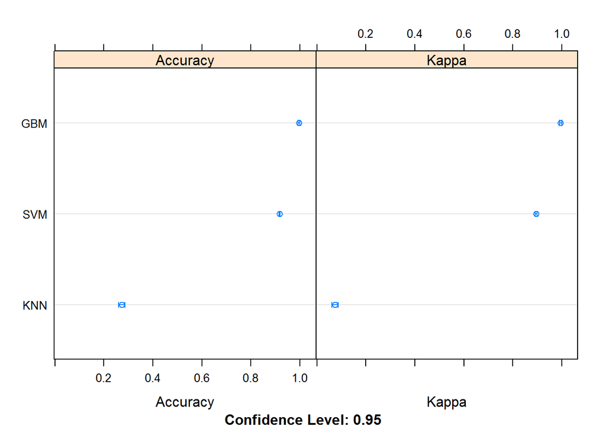

```r
dotplot(results)
```

KNN is really not good. We are going to use GBM to predict.

```r
predictions <- predict(gbm_model, test)
confusionMatrix(predictions, test$classe)
```

```
## Confusion Matrix and Statistics
##
##           Reference
## Prediction    1    2    3    4    5
##          1 1116    2    0    0    0
##          2    0  756    1    0    0
##          3    0    1  682    1    0
##          4    0    0    1  640    2
##          5    0    0    0    2  719
##
## Overall Statistics
##
##                Accuracy : 0.9975
##                  95% CI : (0.9953, 0.9988)
##     No Information Rate : 0.2845
##     P-Value [Acc > NIR] : < 2.2e-16
##
##                   Kappa : 0.9968
##  Mcnemar's Test P-Value : NA
##
## Statistics by Class:
##
##                      Class: 1 Class: 2 Class: 3 Class: 4 Class: 5
## Sensitivity            1.0000   0.9960   0.9971   0.9953   0.9972
## Specificity            0.9993   0.9997   0.9994   0.9991   0.9994
## Pos Pred Value         0.9982   0.9987   0.9971   0.9953   0.9972
## Neg Pred Value         1.0000   0.9991   0.9994   0.9991   0.9994
## Prevalence             0.2845   0.1935   0.1744   0.1639   0.1838
## Detection Rate         0.2845   0.1927   0.1738   0.1631   0.1833
## Detection Prevalence   0.2850   0.1930   0.1744   0.1639   0.1838
## Balanced Accuracy      0.9996   0.9979   0.9982   0.9972   0.9983
```

Now let’s predict on pml-testing

```r
pml_testing <- read.csv("pml-testing.csv", stringsAsFactors = F, na.strings = c("NA", ""))
pml_testing <- subset(pml_testing, select = -c(X, user_name, cvtd_timestamp))
pml_testing <- pml_testing[!(colSums(is.na(pml_testing)) > 0)]
pml_testing[pml_testing$new_window == "no", "new_window"] <- 1
pml_testing[pml_testing$new_window == "yes", "new_window"] <- 2
pml_testing$new_window <- as.integer(pml_testing$new_window)
pml_testing$new_window <- as.factor(pml_testing$new_window)
predictions <- predict(gbm_model, pml_testing)

predictions
```

```
##  [1] 2 1 2 1 1 5 4 2 1 1 2 3 2 1 5 5 1 2 2 2
## Levels: 1 2 3 4 5
```

Here’s my predictions:

B A B A A E D B A A B C B A E E A B B B